# Data Science For Lawyers Course

# Lesson One - Getting Started

Edits, additions, and Swirl integration by: Amanda Lim, Bhavya Gupta

Original Author: Wolfgang Alschner

### Foreword

This file accompanies interactive Swirl lessons written by Amanda Lim and Bhavya Gupta as part of a project initiated by UCL Data Science Society. You may use this file to learn or reference it as an answer key to the interactive lessons.*

*Disclaimer:*

These lessons are based on workshops original created by Wolfgang Alschner , a Professor at the University of Ottawa. UCL Data Science Society does not take any credit for the creation of this material, except where additions/edits were made. Swirl integration, additional material and questions, as well as the Jupyter notebook were created by Amanda Lim and Bhavya Gupta as part of a project initiated by the UCL Data Science Society. Visit http://www.datascienceforlawyers.org/learning-resources/ to view the original workshops.

*Version: June 2020*

### Section One - Basic Calculations in R

Author - Wolfgang Alschner

Edits - Amanda Lim

Version - March 2018, Edits May 2020

Throughout the lesson, we’ll be using terms like “console” and “script”.

The CONSOLE is the bottom left pane in RStudio. All code that is run, as well as the output of that code, will show up here. You can also type in code directly into the CONSOLE and execute it, but this won’t be saved. The CONSOLE is useful for when you want to quickly execute one line of code.

Most of our exercises will be done in the CONSOLE, but feel free to save your answers in the SCRIPT if you’d like.

In simple terms, R is a calculator. You enter an equation and it returns the answer. Let’s try this with a few examples.

*Type in “1+1” in your R console.*

```r
1+1
```

```
## [1] 2
```

Notice how R returns “2”, the answer to what you entered.

Let’s move on to some other calculations. Here are some other operations in R…

```r
#Division
16/4
```

```
## [1] 4
```

```r
#Multiplication:
5*5
```

```
## [1] 25
```

```r
#Exponents
3^2
```

```
## [1] 9
```

*Divide 10 by 2 in your console.*

```r
10/2
```

```
## [1] 5
```

You can add COMMENTS to your code in the script using #. This way, R will understand that this part of your script is a comment and as such will not execute this part. Using comments in your script is useful, because it explains what your code is doing to the others who are reading your code or to yourself after returning to it after some time. You should comment your code as much as possible. It will make your life easier!

Comments are used in the R Script since that code is executed time and time again.

*Try adding a comment using # into your R script now; it should turn a different colour!*

```r
# This is a comment
# This is another comment
```

In addition to performing calculations, you can also store information you have created. In the upper right hand corner of RStudio, you can see the ENVIRONMENT. Here, you see all variables you have created and their corresponding values.

You store values in variables using an arrow “<-” like so:

```r
v<-10
```

*Let’s try. Assign the value of 1 to the variable x.*

```r
x<-1
```

*Now assign 2+2 to a variable y.*

```r
y <- 2+2
```

Both x and y should show up in the top right hand pane in RStudio called “Environment”. Check your Environment in RStudio now to see them.Notice how the value of y is equal to 4. R automatically added 2+2 for us. How cool!

To print the information you have stored in a variable, you can either type in the name of the variable in the script or console or use print(). To tell R to print out the value of a variable, put that variable inside the brackets when typing print().

*Let’s try printing variable y using print().*

```r
print(y)
```

```
## [1] 4
```

Notice above that R “spits out” the answer. You can also perform operations with variables that have values assigned to them.

*Add variables x and y together in the console.*

```r
x+y
```

```
## [1] 5
```

We call these variables you create OBJECTS. You have almost complete liberty to name your object. All of the following are objects:

```r
silly_name <- 5+3

v <- silly_name

number_of_planets <- 7
```

The values of objects appear in the “Environment” in RStudio once you execute the code.These values can be updated and changed at any time; you just have to change the value and hit cmd-enter again in the Script.

### Section Two - Object Classes

Author - Wolfgang Alschner

Edits - Amanda Lim

Version - March 2018

R powerful is a powerful tool because you can work with numbers and with other types of data.

More specifically, there are three types of data objects that we will use.

- numerical objects e.g. 1; 67; 5.56541
- logical objects i.e. TRUE, FALSE
- character objects e.g. “Hello World”

To determine the type of data object something is, you simply do class(). For example:

```r
class(silly_name)
```

```
## [1] "numeric"
```

If we executed this code, R would spit out “numeric”. This makes sense since we told R that silly_name was 5+3.

*Define a variable another_silly_name with the value: “Hello World”.*

```r
another_silly_name <- "Hello World"
```

*Now, let’s ask R in the console what the class of another_silly_name is by using class().*

```r
class(another_silly_name)
```

```
## [1] "character"
```

Commands like class() or print() are FUNCTIONS. You can perform functions on R objects.

Whenever you do not know what a funciton does, you can ask R using ?function_name(). For example:

```r
?class()
```

Up to now, we have been dealing with single values: one integer or one string. You can aggregate these values into VECTORS.

To do so you aggregate values with c().

numeric_vector <- c ( 1 , 2 , 3 , 4 , 5 )

*Define a vector called my_numerical_vector with the numbers 5,4,3,2,1.*

```r
my_vector <- c(5,4,3,2,1)
```

Nice! my_vector is in your Environment now too. You can also create vectors with character strings as well, like so:

```r
character_vector <- c ( "Days" , "Months" , "Year" )
```

*Create a character vector called my_character_vector with the words “Monday”, “Tuesday”, “Wednesday”.*

```r
my_character_vector <- c("Monday", "Tuesday", "Wednesday")
```

That one shows up in our environment too.

In turn, vectors can be aggregated into MATRICES and DATAFRAMES. Both are essentially tables. The difference is that matrices must be one type of data whereas dataframes can combine different types of data. We will work mostly with dataframes. Typically, you will load dataframes from external sources.

As an example, take a look at one of the in-built dataframe of R (“USArrests”) that provides crime statistics of US states.

*Type data(“USArrests”) into the console.*

```r
data("USArrests")
```

Now R knows to use the dataset USArrests. USArrests is also now in the envronment under “Data”.

*Now type print(USArrests) to view the dataset.*

```r
print(USArrests)
```

```
##                Murder Assault UrbanPop Rape
## Alabama          13.2     236       58 21.2
## Alaska           10.0     263       48 44.5
## Arizona           8.1     294       80 31.0
## Arkansas          8.8     190       50 19.5
## California        9.0     276       91 40.6
## Colorado          7.9     204       78 38.7
## Connecticut       3.3     110       77 11.1
## Delaware          5.9     238       72 15.8
## Florida          15.4     335       80 31.9
## Georgia          17.4     211       60 25.8
## Hawaii            5.3      46       83 20.2
## Idaho             2.6     120       54 14.2
## Illinois         10.4     249       83 24.0
## Indiana           7.2     113       65 21.0
## Iowa              2.2      56       57 11.3
## Kansas            6.0     115       66 18.0
## Kentucky          9.7     109       52 16.3
## Louisiana        15.4     249       66 22.2
## Maine             2.1      83       51  7.8
## Maryland         11.3     300       67 27.8
## Massachusetts     4.4     149       85 16.3
## Michigan         12.1     255       74 35.1
## Minnesota         2.7      72       66 14.9
## Mississippi      16.1     259       44 17.1
## Missouri          9.0     178       70 28.2
## Montana           6.0     109       53 16.4
## Nebraska          4.3     102       62 16.5
## Nevada           12.2     252       81 46.0
## New Hampshire     2.1      57       56  9.5
## New Jersey        7.4     159       89 18.8
## New Mexico       11.4     285       70 32.1
## New York         11.1     254       86 26.1
## North Carolina   13.0     337       45 16.1
## North Dakota      0.8      45       44  7.3
## Ohio              7.3     120       75 21.4
## Oklahoma          6.6     151       68 20.0
## Oregon            4.9     159       67 29.3
## Pennsylvania      6.3     106       72 14.9
## Rhode Island      3.4     174       87  8.3
## South Carolina   14.4     279       48 22.5
## South Dakota      3.8      86       45 12.8
## Tennessee        13.2     188       59 26.9
## Texas            12.7     201       80 25.5
## Utah              3.2     120       80 22.9
## Vermont           2.2      48       32 11.2
## Virginia          8.5     156       63 20.7
## Washington        4.0     145       73 26.2
## West Virginia     5.7      81       39  9.3
## Wisconsin         2.6      53       66 10.8
## Wyoming           6.8     161       60 15.6
```

### Section Three - Accessing and Manipulating Data

Author - Wolfgang Alschner

Edits - Amanda Lim

Version - March 2018, Edits June 2020

There are different commands you can use to access data in your R objects, and their use differs slightly between object classes. To access an item in a list, just indicate its place within the vector through [ ].

*Try creating a vector called fruit_vector with the words “Apple”, “Banana”, and “Orange”, in that order.*

```r
fruit_vector <- c("Apple", "Banana", "Orange")
```

*Now, access the second item in the list by typing fruit_vector[2].*

```r
fruit_vector[2]
```

```
## [1] "Banana"
```

See how R spits out the second item in the vector? Pretty cool right!

If you are unsure about the location of given information in a list, use the which() function.

For example, the code below will give you the location of the word apple in the vector fruit_vector.

```r
which(fruit_vector == "Apple")
```

```
## [1] 1
```

*Use the which() function to determine the location of the word “Orange” in fruit-vector.*

```r
which(fruit_vector == "Orange")
```

```
## [1] 3
```

Most of the time we work with dataframes. Dataframes have two dimensions - rows and columns. Just like a table. When using [ ] to access values in dataframes, R has an in-built ordering of placing rows before columns i.e. dataframe[row,columm].

So when you want to access data on “Arkansas” (4th row) on “Murder” (1st column), you would write:

```r
USArrests[4,1]
```

```
## [1] 8.8
```

*Try asking R to show us the data entry on “Arizona” (3rd row) on “Assault” (2nd column) of the USArrests dataframe.*

```r
USArrests[3,2]
```

```
## [1] 294
```

Notice how R spits out just a single number? That’s because we told it to give us whatever is in row 3, column 2 of the USArrests dataframe. Nice!

If you are interested in all columns for Arkansas just leave the space behind the comma blank.

*Try accessing all the data on “Arkansas” (row 4) in all columns.*

```r
USArrests[4,]
```

```
##          Murder Assault UrbanPop Rape
## Arkansas    8.8     190       50 19.5
```

Similarly, if you are interested in murder rates (column 1) for all states (all rows) just leave the space in front of the comma blank.

```r
USArrests[,1]
```

```
##  [1] 13.2 10.0  8.1  8.8  9.0  7.9  3.3  5.9 15.4 17.4  5.3  2.6 10.4  7.2  2.2
## [16]  6.0  9.7 15.4  2.1 11.3  4.4 12.1  2.7 16.1  9.0  6.0  4.3 12.2  2.1  7.4
## [31] 11.4 11.1 13.0  0.8  7.3  6.6  4.9  6.3  3.4 14.4  3.8 13.2 12.7  3.2  2.2
## [46]  8.5  4.0  5.7  2.6  6.8
```

There are alternative ways to get to the same information. To access only the murder rates in the USArrests dataframe, you can call the column name:

```r
USArrests["Murder"]
```

```
##                Murder
## Alabama          13.2
## Alaska           10.0
## Arizona           8.1
## Arkansas          8.8
## California        9.0
## Colorado          7.9
## Connecticut       3.3
## Delaware          5.9
## Florida          15.4
## Georgia          17.4
## Hawaii            5.3
## Idaho             2.6
## Illinois         10.4
## Indiana           7.2
## Iowa              2.2
## Kansas            6.0
## Kentucky          9.7
## Louisiana        15.4
## Maine             2.1
## Maryland         11.3
## Massachusetts     4.4
## Michigan         12.1
## Minnesota         2.7
## Mississippi      16.1
## Missouri          9.0
## Montana           6.0
## Nebraska          4.3
## Nevada           12.2
## New Hampshire     2.1
## New Jersey        7.4
## New Mexico       11.4
## New York         11.1
## North Carolina   13.0
## North Dakota      0.8
## Ohio              7.3
## Oklahoma          6.6
## Oregon            4.9
## Pennsylvania      6.3
## Rhode Island      3.4
## South Carolina   14.4
## South Dakota      3.8
## Tennessee        13.2
## Texas            12.7
## Utah              3.2
## Vermont           2.2
## Virginia          8.5
## Washington        4.0
## West Virginia     5.7
## Wisconsin         2.6
## Wyoming           6.8
```

This would be the same as indicating the column.

*Try accessing the data in the column “Assault” now.*

```r
USArrests["Assault"]
```

```
##                Assault
## Alabama            236
## Alaska             263
## Arizona            294
## Arkansas           190
## California         276
## Colorado           204
## Connecticut        110
## Delaware           238
## Florida            335
## Georgia            211
## Hawaii              46
## Idaho              120
## Illinois           249
## Indiana            113
## Iowa                56
## Kansas             115
## Kentucky           109
## Louisiana          249
## Maine               83
## Maryland           300
## Massachusetts      149
## Michigan           255
## Minnesota           72
## Mississippi        259
## Missouri           178
## Montana            109
## Nebraska           102
## Nevada             252
## New Hampshire       57
## New Jersey         159
## New Mexico         285
## New York           254
## North Carolina     337
## North Dakota        45
## Ohio               120
## Oklahoma           151
## Oregon             159
## Pennsylvania       106
## Rhode Island       174
## South Carolina     279
## South Dakota        86
## Tennessee          188
## Texas              201
## Utah               120
## Vermont             48
## Virginia           156
## Washington         145
## West Virginia       81
## Wisconsin           53
## Wyoming            161
```

Alternatively, to access the data in a column in a dataframe we can also use the $ character.

For example, the code below means to access all the data in the column “Assault” in the dataset USArrests.

```r
USArrests$Assault
```

```
##  [1] 236 263 294 190 276 204 110 238 335 211  46 120 249 113  56 115 109 249  83
## [20] 300 149 255  72 259 178 109 102 252  57 159 285 254 337  45 120 151 159 106
## [39] 174 279  86 188 201 120  48 156 145  81  53 161
```

*Try using this method to access all the data in the column “UrbanPop”*

```r
USArrests$UrbanPop
```

```
##  [1] 58 48 80 50 91 78 77 72 80 60 83 54 83 65 57 66 52 66 51 67 85 74 66 44 70
## [26] 53 62 81 56 89 70 86 45 44 75 68 67 72 87 48 45 59 80 80 32 63 73 39 66 60
```

You can combine the above $ and [ ] approaches. For instance, to again get the murder rates in Arkansas (row 4), you can write:

```r
USArrests$Murder[4]
```

```
## [1] 8.8
```

*Try using this method to access the Urban Population in California (row 5)*

```r
USArrests$UrbanPop[5]
```

```
## [1] 91
```

Sometimes we are only interested in subsets of the data, we then create objects from larger dataframes. Data scientists usually do this if they aren’t working with part of a data, and don’t need it.

For instance, say we want to create a new dataframe that only has the murder rate data. We’d write:

```r
murder_rate <- USArrests["Murder"]
```

Now, whenever we use or access the new dataframe, murder_rate, R will only show us the data in the column “Murder” in USArrests.

*Try creating the murder_rate dataframe by copying the code above.*

If we want to exclude murder rates from our dataset, then we can simply write [,-1] which will eliminate the first column.

*Create a new object called other_crimes removing the first column out of USArrests.*

```r
other_crimes <- USArrests[,-1]
```

*Now let’s print out other_crimes using print().*

```r
print(other_crimes)
```

```
##                Assault UrbanPop Rape
## Alabama            236       58 21.2
## Alaska             263       48 44.5
## Arizona            294       80 31.0
## Arkansas           190       50 19.5
## California         276       91 40.6
## Colorado           204       78 38.7
## Connecticut        110       77 11.1
## Delaware           238       72 15.8
## Florida            335       80 31.9
## Georgia            211       60 25.8
## Hawaii              46       83 20.2
## Idaho              120       54 14.2
## Illinois           249       83 24.0
## Indiana            113       65 21.0
## Iowa                56       57 11.3
## Kansas             115       66 18.0
## Kentucky           109       52 16.3
## Louisiana          249       66 22.2
## Maine               83       51  7.8
## Maryland           300       67 27.8
## Massachusetts      149       85 16.3
## Michigan           255       74 35.1
## Minnesota           72       66 14.9
## Mississippi        259       44 17.1
## Missouri           178       70 28.2
## Montana            109       53 16.4
## Nebraska           102       62 16.5
## Nevada             252       81 46.0
## New Hampshire       57       56  9.5
## New Jersey         159       89 18.8
## New Mexico         285       70 32.1
## New York           254       86 26.1
## North Carolina     337       45 16.1
## North Dakota        45       44  7.3
## Ohio               120       75 21.4
## Oklahoma           151       68 20.0
## Oregon             159       67 29.3
## Pennsylvania       106       72 14.9
## Rhode Island       174       87  8.3
## South Carolina     279       48 22.5
## South Dakota        86       45 12.8
## Tennessee          188       59 26.9
## Texas              201       80 25.5
## Utah               120       80 22.9
## Vermont             48       32 11.2
## Virginia           156       63 20.7
## Washington         145       73 26.2
## West Virginia       81       39  9.3
## Wisconsin           53       66 10.8
## Wyoming            161       60 15.6
```

Notice how the first column, “Murder”, isn’t there anymore?

Now what if we wanted to add it back?

In order to combine datasets, we use two functions. The function rbind() glues two datasets together by their rows, while cbind() connects them by their columns.

Note that in order for cbind() to work, the dataframes must have common rows.And similarily, for rbind() to work, the dataframes must have common columns.If we tried to use these functions on two dataframes with no like columns/rows, it won’t work!

*Use cbind() to combine murder_rate and other_crimes, and assign it to a new dataframe called full_dataset.*

```r
full_dataset <- cbind(murder_rate, other_crimes)
```

***Now print out full_dataset.**

```r
print(full_dataset)
```

```
##                Murder Assault UrbanPop Rape
## Alabama          13.2     236       58 21.2
## Alaska           10.0     263       48 44.5
## Arizona           8.1     294       80 31.0
## Arkansas          8.8     190       50 19.5
## California        9.0     276       91 40.6
## Colorado          7.9     204       78 38.7
## Connecticut       3.3     110       77 11.1
## Delaware          5.9     238       72 15.8
## Florida          15.4     335       80 31.9
## Georgia          17.4     211       60 25.8
## Hawaii            5.3      46       83 20.2
## Idaho             2.6     120       54 14.2
## Illinois         10.4     249       83 24.0
## Indiana           7.2     113       65 21.0
## Iowa              2.2      56       57 11.3
## Kansas            6.0     115       66 18.0
## Kentucky          9.7     109       52 16.3
## Louisiana        15.4     249       66 22.2
## Maine             2.1      83       51  7.8
## Maryland         11.3     300       67 27.8
## Massachusetts     4.4     149       85 16.3
## Michigan         12.1     255       74 35.1
## Minnesota         2.7      72       66 14.9
## Mississippi      16.1     259       44 17.1
## Missouri          9.0     178       70 28.2
## Montana           6.0     109       53 16.4
## Nebraska          4.3     102       62 16.5
## Nevada           12.2     252       81 46.0
## New Hampshire     2.1      57       56  9.5
## New Jersey        7.4     159       89 18.8
## New Mexico       11.4     285       70 32.1
## New York         11.1     254       86 26.1
## North Carolina   13.0     337       45 16.1
## North Dakota      0.8      45       44  7.3
## Ohio              7.3     120       75 21.4
## Oklahoma          6.6     151       68 20.0
## Oregon            4.9     159       67 29.3
## Pennsylvania      6.3     106       72 14.9
## Rhode Island      3.4     174       87  8.3
## South Carolina   14.4     279       48 22.5
## South Dakota      3.8      86       45 12.8
## Tennessee        13.2     188       59 26.9
## Texas            12.7     201       80 25.5
## Utah              3.2     120       80 22.9
## Vermont           2.2      48       32 11.2
## Virginia          8.5     156       63 20.7
## Washington        4.0     145       73 26.2
## West Virginia     5.7      81       39  9.3
## Wisconsin         2.6      53       66 10.8
## Wyoming           6.8     161       60 15.6
```

Nice! Notice how the “Murder” column is back now, and that the two dataframes were combined using cbind() based on their common rows (the states).

### Section Four - Plotting Data

Author - Wolfgang Alschner

Edits - Bhavya Gupta

Version - March 2018, Edits June 2020

Say there was a number of disputes in a Law firm over a given period of time. What if we wanted to graph these in R?

Let’s create a dataset of numbers of claims per year. *First define a vector ‘year’ containing years 2008 to 2017*

```r
year <- c( 2008:2017)
```

*Now, Assign the following values to a vector “Claims”: 32,45,67,98,112,77,67,98,103,88*

```r
claims <- c(32,45,67,98,112,77,67,98,103,88)
```

*Next, assign these two vectors to a data frame called “disputes”.*

```r
disputes <- data.frame(year, claims)
```

*Now, print this data frame.*

```r
print(disputes)
```

```
##    year claims
## 1  2008     32
## 2  2009     45
## 3  2010     67
## 4  2011     98
## 5  2012    112
## 6  2013     77
## 7  2014     67
## 8  2015     98
## 9  2016    103
## 10 2017     88
```

This gives us a table of claims in each year. We can visualise the data using the plot() function.

*Put “disputes”, the name of the dataframe, inside the brackets to plot it.*

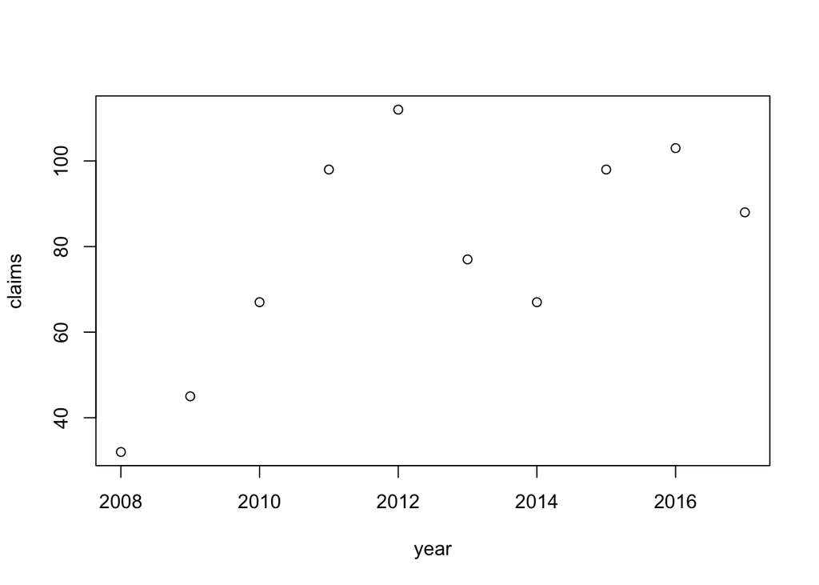

```r
plot(disputes)
```

Nice! The plot should show up in the bottom right hand pane called “Plots”. Take a look at the graph now.

The plot() function, like other functions, in R has default settings. Want to know how the function can be customized to generate some really cool graphs?

Consult the R Document to learn how the function can be customized. Simply enter-

```r
?plot()
```

*Enter it into your console now.*

Take a look at the bottom right hand pane to read. You can use the ?function() with any function in R to see what it does, and how to write the code.

This will help with the following questions.

Now let’s add axis labels and title to our graph. Remember that arguments go inside the brackets of the function with commas separating them.

An example:

```r
# plot(x,y,type = "p", xlab = "x axis label", ylab = "y axis label", main = "My Graph's Title")
```

For our graph, make the type of the graph points (p), x axis “Year”, the y axis “Claims”, and the main title “Claims per Year”.

Remember that we’re plotting years on the x axis (the variable name will replace argument “x”), and claims on the y axis (the variable name will replace argument “y”.

*Type in the code for this graph:*

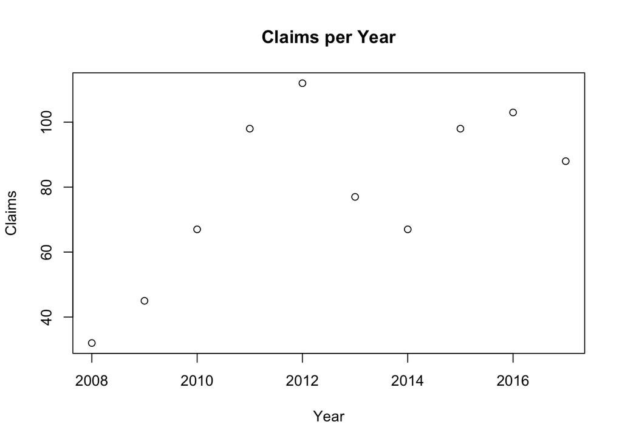

```r
plot(disputes$year,disputes$claims, type = "p", xlab="Year", ylab="Claims", main = "Claims per Year")
```

Notice how there’s now title and axis labels we specified?

*Tip: Use the blue arrows to toggle back and forth between previous plots.*

What if we wanted to add lines and change the colour of the points? Remember that type = b means we want BOTH points and lines, and that col = “blue” means that we want the points and lines to be blue.

*Add the above arguments into the plot() code you wrote in the last question. Start with type, then col, then continue with xlab.*

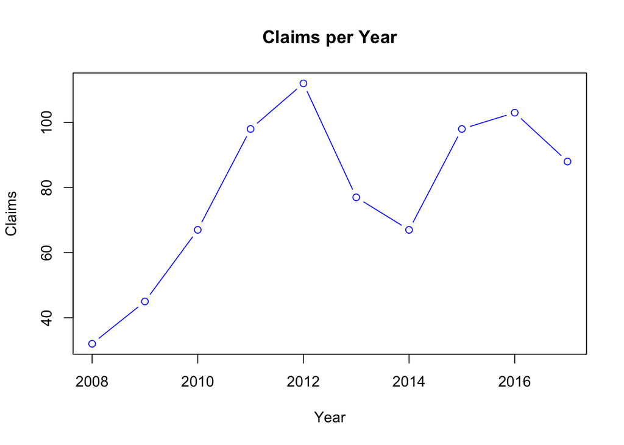

```r
plot(disputes$year,disputes$claims, type = "b", col="blue", xlab="Year", ylab="Claims", main = "Claims per Year")
```

Notice how there’s blue lines and points now? Super cool!

We can even plot text labels in R using the function text() in combination with plot(). For instance, here we imagine that there were 3 different judges over our timeframe, which in turn had an impact on the data.

Let’s say 2008 to 2010 had judge Parker, 2011 to 2013 had judge Colbert, and 2014 to 2017 had judge Jones.

In order to have text labels show up on our graph, we need to create an object listing them.

*Let’s start by assigning the three judges to a vector. Keep in mind that if the judges worked for more than one year, you must re-write their names more than once.Call this vector “judges”.*

```r
judges <- c("Parker","Parker","Parker","Colbert","Colbert","Colbert","Jones","Jones","Jones","Jones")
```

*Now, re-write the dataframe “disputes” and add the “judges” vector.*

```r
disputes <- cbind(disputes, judges)
```

*Now, print the data and see what happens.*

```r
print(disputes)
```

```
##    year claims  judges
## 1  2008     32  Parker
## 2  2009     45  Parker
## 3  2010     67  Parker
## 4  2011     98 Colbert
## 5  2012    112 Colbert
## 6  2013     77 Colbert
## 7  2014     67   Jones
## 8  2015     98   Jones
## 9  2016    103   Jones
## 10 2017     88   Jones
```

Now we can see the names of the judges corresponding to the claims.

What if we wanted to add the names of the judges to our existing plot? We do this by using the text() function to add the text, i.e. the names of the judges. We do this with the following code:

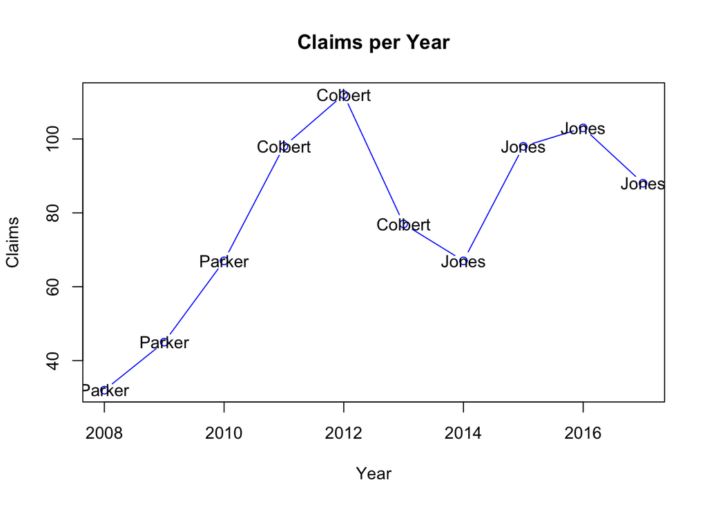

```r
# Editor's note: Code included for HTML functionality. Ignore these lines!
plot(disputes$year,disputes$claims, type = "b", col="blue", xlab="Year", ylab="Claims", main = "Claims per Year")

# Editor's note: This is the answer!
text(disputes$year,disputes$claims, label=disputes$judges)
```

*Copy this new line of code and see what happens.*

Now we can see exactly which judge corresponded to which claim.

### Section Five - Basic String Operations

Author - Wolfgang Alschner

Edits - Bhavya Gupta

Version - March 2018, Edits June 2020

In this course, we will often be dealing with text data. These are also called character strings in R.

*Create a character vector called ‘example’, which contains the words, “Hello World”*

```r
example <- "Hello World"
```

To merge two strings we can use the paste() function. This function uses a separator which is by default " " ( a space), i.e. the two strings joined together will be separated by a space.

*Create two strings , “Hello World” and “how is your day” and join them. Call this “new_example”.*

```r
new_example <- paste("Hello World", "how is your day")
```

We can also change the separator by adding an argument in the paste() function : sep= “,”

In this case, we have chosen the separator as a comma, but you can insert anything you like.

*Go ahead and try it!*

```r
new_example <- paste("Hello World", "how is your day", sep=", ")
```

*Now print new_example.*

```r
print(new_example)
```

```
## [1] "Hello World, how is your day"
```

To split a string we can use the strsplit() function.

*How would you split the string you just created?*

```r
strsplit(new_example, ",")
```

```
## [[1]]
## [1] "Hello World"      " how is your day"
```

When using the strsplit()function, R returns us a nested list. To access only the elements of the sublist we can ask for the first element in the sublist [[1]].

*Just insert the sublist after strsplit().*

```r
strsplit(new_example, ",")[[1]]
```

```
## [1] "Hello World"      " how is your day"
```

As you will see in the remainder of the course, some functions return nested lists. This is a frequent source of trouble for people who are new to R. So if you have difficulties accessing specific elements in a vector, check to see whether you are dealing with a sublist.

Author - Wolfgang Alschner

Edits - Bhavya Gupta

Version - March 2018, Edits June 2020

It is often useful to apply a function to all of the elements in a vector or a data frame, rather than just applying it to one. For that we use a loop. Imagine you want to multiply the numbers 20 to 29 by 13. You can write 20*13, 21*13, 22*13 … A loop does that work for you.

*First, let’s create a number list and print it. Call this list “number_list”.*

```r
number_list <- c(20:29)
```

*Now print this number list.*

```r
print(number_list)
```

```
##  [1] 20 21 22 23 24 25 26 27 28 29
```

In this example, we want to tell R to repeat “13 operation for all 10 elements and print the result.”

We thus write a for loop like this: for each elements (20,21,22 …) in my list multiply that element by 13. Note that the variable “element” could have any name, e.g. “i”: for (i in number_list) {print (i*13)}.

*Now perform this operation (multiplication with the number 13) for each element in the number list.*

```r
for (element in number_list) { print(element*13) }
```

```
## [1] 260
## [1] 273
## [1] 286
## [1] 299
## [1] 312
## [1] 325
## [1] 338
## [1] 351
## [1] 364
## [1] 377
```

We can also write the same loop without using the value of the element, but instead use its rank in the vector. That means we perform the function on the first element of the list, then the second and so on. This becomes useful when we want to access the same rank in different vectors. So how many ranks does our list have?

*To find out, use the function length() and put the name of the list inside.*

```r
length(number_list)
```

```
## [1] 10
```

*Now try writing the code: for the ranks from 1 to length of list (here 10), perform a function on each element of that rank.*

```r
for (rank in 1:length(number_list)) {print(number_list[rank]*13)}
```

```
## [1] 260
## [1] 273
## [1] 286
## [1] 299
## [1] 312
## [1] 325
## [1] 338
## [1] 351
## [1] 364
## [1] 377
```

Both approaches yield the same result, but use a different grammar. You can see that when you print element and rank.

*First, print element.*

```r
print(element)
```

```
## [1] 29
```

*Now, print “rank”.*

```r
print(rank)
```

```
## [1] 10
```

Let’s try a loop on the on a dataframe.

This is just a sample dataframe with 3 rows and 4 columns. Since this is slightly harder to try, here’s the code for you. sample_dataframe <- as.data.frame(matrix(data=1:12, nrow=3, ncol=4, byrow=FALSE))

*Now create this dataframe.*

```r
sample_dataframe <- as.data.frame(matrix(data=1:12, nrow=3, ncol=4, byrow=FALSE))
```

*Now, print this dataframe.*

```r
print(sample_dataframe)
```

```
##   V1 V2 V3 V4
## 1  1  4  7 10
## 2  2  5  8 11
## 3  3  6  9 12
```

Now, we want to know the sum of each of the three rows and columns. *What do you think the loop would look like?*

```r
for (row in 1:nrow(sample_dataframe)) { print(sum(sample_dataframe[row,])) }
```

```
## [1] 22
## [1] 26
## [1] 30
```

*Now try doing this for columns instead.*

```r
for (col in 1:ncol(sample_dataframe)) {print(sum(sample_dataframe[,col])) }
```

```
## [1] 6
## [1] 15
## [1] 24
## [1] 33
```

Feel free to re-take this course anytime. If you want to reference the material in this lesson without having to go through each question step-by-step, refer to the HTML file for this lesson.

We hope you had fun on our first lesson!

Sincerely, Amanda Lim and Bhavya Gupta

End of Lesson One - Getting Started